# COM 903 · Inference and Identification

COM 903 Advanced Research Methods in Communication Jacob T. Fisher, Ph.D.

## Inference and identification

Frequentist inference · Bayesian inference · Causal diagrams

## Rewind: credibility

- On September 14, we asked what makes a research claim *credible*, and saw that replication is only one part of the answer.
- We split credibility into four validities (Vazire et al., 2022): construct, internal, external, and statistical conclusion validity.
- Today focuses on two of them:
  - **Inference** – what the data say about a quantity, given a model (statistical conclusion validity).
  - **Identification** – whether that quantity is the causal effect we care about (internal validity).

Construct

Internal→ identification

External

Statistical conclusion→ inference

## Learning objectives

By the end of today, you should be able to:

- **Explain** what a *p* value and a confidence interval do (and don’t) tell you, and the view of probability they come from.
- **Describe** where Bayesian inference came from and where it has proven especially useful.
- **Interpret** a prior, a posterior, a credible interval, and a Bayes factor.
- **Express** a theory’s prediction as a prior, and compare theories by how well they predicted the data.
- **Distinguish** a DAG from the box-and-arrow diagrams common in our field, and use one to decide what to control for.

## Why it matters

- Nearly every quantitative claim in our field makes two moves: an *inferential* one (what do these data say?) and a *causal* one (what produced them?).
  - **Media psychology**: “Does a liked character’s fate change how much people enjoy a story?”
  - **Health communication**: “Did the anti-vaping campaign reduce vaping, or did lower-risk teens just see more of it?”
  - **Political communication**: “Does partisan news increase polarization, or do polarized people seek it out?”
- By the end of today, you’ll be able to say what a result supports, choose the framework that matches your question, and identify what your design needs before a result can be read causally.

## Research example: one good deed, two endings

- Participants read a story in which the main character finds a lost wallet and returns it with the cash untouched.
- They’re randomly assigned to one of two endings: the owner gives the character a **cash reward**, or accuses them of theft and **calls the police**.
- Everyone rates how much they **enjoyed the story**, from 1 (not at all) to 7 (very much).
- **Affective disposition theory** (ADT), developed by Dolf Zillmann and colleagues in the 1970s, predicts that we enjoy seeing liked characters rewarded (Raney, 2004).
- The data are simulated, so we know the true effect and can check which interpretations were warranted.

**Good + Rewarded**  
returns the wallet, gets a cash reward

→

**higher**  
enjoyment

**Good + Punished**  
returns the wallet, accused of theft

→

**lower**  
enjoyment

ADT's prediction: rewarded − punished > 0

A study reports a 0.42-point difference in story enjoyment, 95% CI [−0.01, 0.85], *p* = .054, with 50 participants per condition.  
Write the sentence you’d put in your results section.

## Roadmap

01

Frequentist inference

02

Bayesian inference

03

Causal identification

## Roadmap

01

Frequentist inference

02

Bayesian inference

03

Causal identification

## What does “probability” mean?

- When a forecast says there’s a 70% chance of rain tomorrow, what is that 70% a probability *of*?
- **Frequentist probability** – the long-run relative frequency of an outcome over many repetitions of the same process (Venn, 1866; von Mises, 1928).
  - …but tomorrow only happens once.
- **Bayesian probability** – a degree of belief in a claim, given the information you have.
- Most of what we cover today follows from this difference. If probability only describes repeatable events, then a parameter or hypothesis can’t have a probability (it is either true or false), and only the data are treated as random.

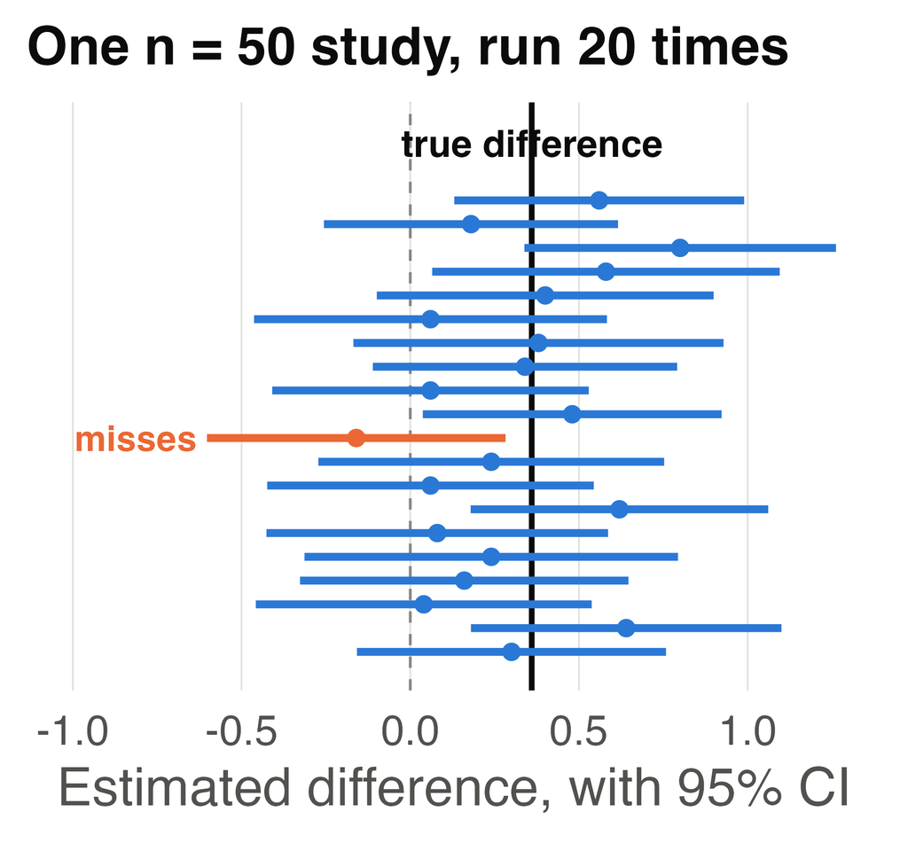

## Fisher and Neyman–Pearson

Fisher (1925)

- **Significance testing** – a *p* value is a graded measure of evidence against a single null hypothesis.
- He treated .05 as a convenient benchmark for results worth a second look.
- Inference is about *this* experiment.

Neyman & Pearson (1933)

- **Hypothesis testing** – a decision rule between two hypotheses, with error rates (α, β) fixed in advance.
- It controls how often you’ll be wrong across many studies, and makes no claim about any single study.
- Neyman later called this “inductive behavior.”
- The procedure most of us learned (compute *p*, compare it to .05, then reject or retain H₀) is a hybrid of the two that neither camp endorsed (Gigerenzer, 2004).

## What a *p* value is

- **p value** – the probability that the test statistic would be at least as extreme as the one observed, *if every assumption of the statistical model were true*, including the test hypothesis (Greenland et al., 2016).

*p* = P( |T| ≥ |t<sub>obs</sub>| ; H₀ + model )

- *T* – the test statistic (here, a *t* statistic); *t*<sub>obs</sub> – the one we observed.
- H₀ + model – the test hypothesis (a true difference of zero), plus every other assumption.
- For our study, *t*(98) = 1.95, so *p* = .054: the shaded area on the right.
- It tests the *whole model*, including random assignment, independence, and the absence of selective reporting, along with H₀.

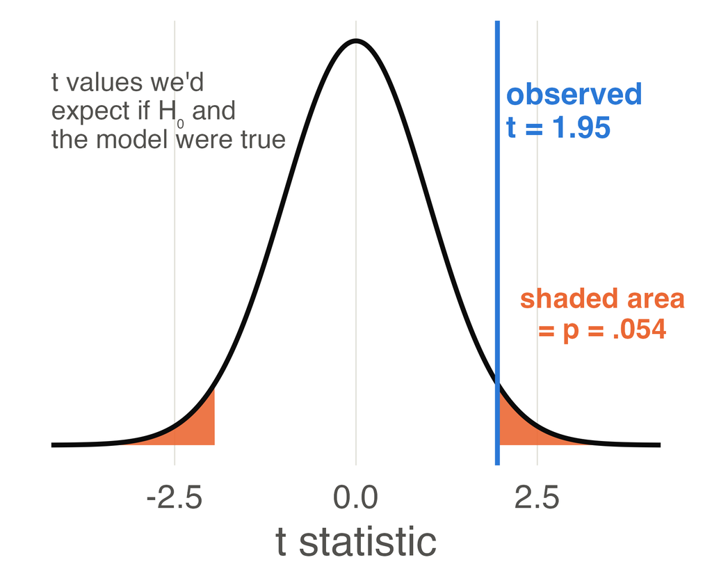

## The transposed conditional

- A *p* value is a probability of *data*, given a hypothesis: P(data this extreme | H₀).
- What we usually want is the reverse: the probability of a *hypothesis*, given the data, P(H₀ | data).
- The two can differ by orders of magnitude.
  - E.g. – P(speaks Spanish | lives in Madrid) is nearly 1, but P(lives in Madrid | speaks Spanish) is under 1%.
- Getting from one to the other takes two more ingredients: **Bayes’ theorem** and a **prior** – how plausible the hypothesis was before the data.
- …which is why frequentist methods don’t report P(H₀ | data).

## Common misreadings (Greenland et al., 2016)

| The claim | What’s actually true |
| --- | --- |
| “*p* = .054, so there’s a 5.4% chance the null is true.” | *p* is computed by *assuming* the null is true. So it can’t also be the probability that the null is true. |
| “*p* > .05, so there’s no effect.” | The CI [−0.01, 0.85] includes zero *and* effects larger than most in our field. A nonsignificant result doesn’t show that the effect is zero. |
| “*p* < .05, so the effect is large or important.” | Significance depends on sample size. Trivial effects are significant in big samples. |
| “There’s a 95% chance the true value is in *this* CI.” | 95% of intervals built this way capture the true value. Whether this particular one did is unknown. |
| “n = 50 (*p* = .054) and n = 150 (*p* < .001) disagree.” | Their estimates (0.42 and 0.47) are nearly identical. Compare the estimates themselves. |

## Reading *p* as compatibility

- Greenland et al. (2016) suggest reading *p* as a measure of *compatibility* between the data and the whole model.
- A 95% CI is then a **compatibility interval** – the range of effect sizes most compatible with the data, given the model.
- Testing every candidate effect (in addition to zero) produces a **p-value function**. Here, 0.42 is most compatible with the data, and 0 and 0.85 are about equally (and only marginally) compatible.
- Before collecting data, name your **smallest effect size of interest** – the smallest effect that would matter for your theory or your audience (Lakens, 2022).

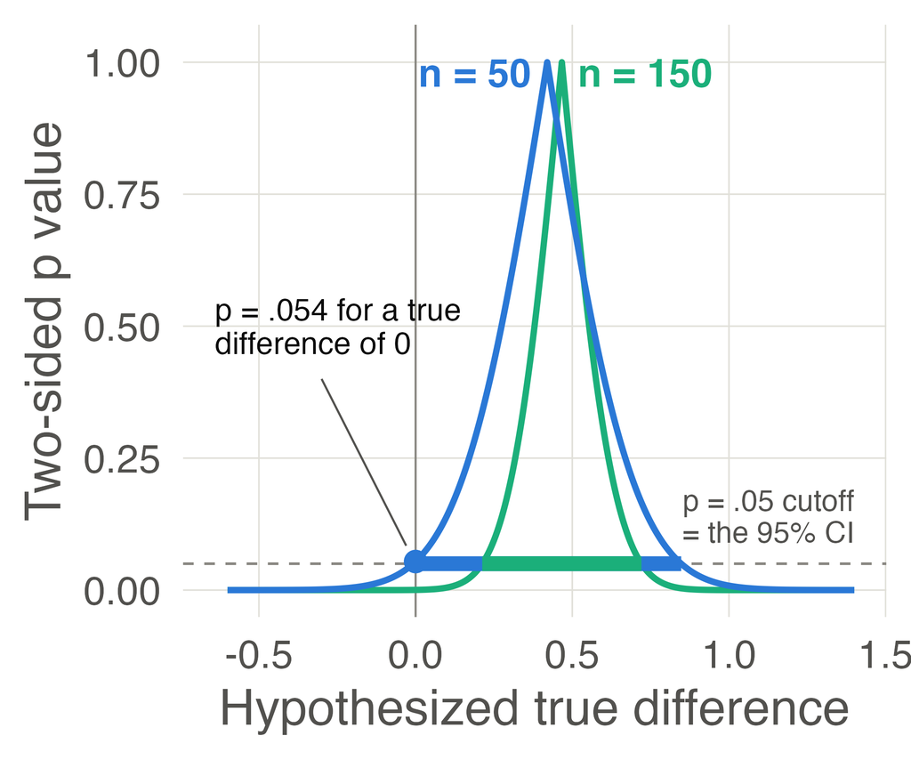

## Reading: Greenland et al. (2016)

- Seven statisticians and epidemiologists wrote this guide, published alongside the American Statistical Association’s 2016 statement on *p* values.
- Their starting point: no interpretation of *p* values, confidence intervals, or power is simple, intuitive, and correct all at once, so shortcut definitions have spread through the literature.
- **Contributions:**
  - Every test is a test of the whole statistical model, including protocol choices like picking analyses by their results.
  - A numbered list of 25 misinterpretations of *p* values, confidence intervals, and power, each with an explanation.
  - Reading *p* and intervals as measures of compatibility, and reporting intervals over significance verdicts.

Assigned readingGreenland, Senn, Rothman, Carlin, Poole, Goodman, & Altman (2016). Statistical tests, *P* values, confidence intervals, and power: A guide to misinterpretations. *European Journal of Epidemiology, 31*, 337–350.

1. Which of Greenland et al.'s misinterpretations have you seen (or written) in a communication paper? What would the corrected sentence say?

2. If a *p* value tests the whole model, what assumptions in your own planned study could produce a small *p* even if your hypothesis is wrong?

## Tradeoffs of frequentist testing

Strengths

- **Error control** – used as designed, a test at α = .05 wrongly rejects a true null no more than 5% of the time, in the long run.
- **No prior** – the analysis depends only on the data model and the design.
- A natural fit with falsification: try hard to refute a hypothesis (Mayo, 2018, calls this “severe testing”).

Limitations

- **No probabilities for hypotheses** – you can reject H₀, but never say how probable H₀ or your theory is.
- **Stopping rules matter** – peeking at the data or changing the stopping rule changes the *p* value for the same data.
- **The nil null is almost always false** – with enough data some difference appears, so rejecting “exactly zero” is a weak test of a theory (Meehl, 1967; Cohen, 1994).

…so what would it take to ask how probable a hypothesis is?

## Demo – Scene 1: same data, two questions

- Open the demo to **Scene 1**. We’ll look at the n = 50 and n = 150 results side by side.
- **Predict first**: the sample triples, and the true effect stays the same. What *p* value do you expect?
- **Watch for**: the p-value function, and why each curve peaks at its own study’s estimate.
- We’ll stop at “The Bayesian question” and come back here.

## Roadmap

01

Frequentist inference

02

Bayesian inference

03

Causal identification

## Where Bayes came from

- The core idea predates Fisher’s significance tests by more than 150 years.
- **Thomas Bayes**, an English minister, worked out how to reason backward from observed data to an unknown cause. **Richard Price** published the essay in 1763, two years after Bayes died.
- **Pierre-Simon Laplace** developed the rule independently and applied it to everything from birth ratios to the mass of Saturn. For a century it was simply “inverse probability.”
- In the early 20th century it fell out of favor, because priors looked subjective and the math for realistic models couldn’t be done by hand.
- …until cheap computing made it practical around 1990.

1763Bayes's essay, published by Price

1774Laplace's "inverse probability"

1925Fisher: inverse probability "must be wholly rejected"

1935–39Jeffreys develops Bayesian hypothesis tests (today's Bayes factor)

1940sTuring weighs evidence against Enigma in "decibans"

1954Savage, *The Foundations of Statistics*

1990Gelfand & Smith: sampling (MCMC) makes posteriors computable

2010sStan, brms, and JASP make Bayesian models routine to fit

## Where Bayesian methods have been useful

Outside our field

- **Codebreaking** – Turing scored guesses about Enigma settings by adding up “decibans” of evidence (Good, 1979).
- **Search** – After two years of failed searches, a Bayesian map of where Air France 447 went down led searchers to the wreck in about a week (Stone et al., 2014).
- **Medicine** – The Pfizer–BioNTech COVID-19 vaccine trial used a Bayesian rule to declare success (Polack et al., 2020).

In our field

- **Small samples** – a reasonable prior stabilizes estimates that the data alone estimate poorly.
- **Nested data** – partial pooling across people, classrooms, or countries.
- **Evidence *for* the null** – boundary conditions and failed replications.
- **Accumulating evidence** – yesterday’s posterior becomes today’s prior.

## Bayes’ theorem, in words

- Bayes’ theorem turns P(data | hypothesis), which is what a *p* value gives you, into P(hypothesis | data).

P(θ | data) = P(data | θ) × P(θ) / P(data)

- **Posterior**, P(θ | data) – what you believe about θ after seeing the data.
- **Likelihood**, P(data | θ) – how well each possible value of θ predicts the data you got.
- **Prior**, P(θ) – what you believed, or what your theory predicted, before the data.
- **Evidence**, P(data) – how well the model *as a whole* predicted the data (it rescales the rest).
- Put simply, the posterior is proportional to the likelihood times the prior. The data update the prior by shifting weight toward values of θ that predicted the data well.

## Example: updating on the n = 50 data

- With a **flat prior** (every difference equally plausible), the posterior is the likelihood: 0.42, 95% credible interval [−0.01, 0.85].
- This supports a direct probability statement: given the model and prior, there’s a 97% probability the rewarded ending was enjoyed more.
- A **skeptical prior**, Normal(0, 0.25), says effects in our field are usually small. It pulls the estimate toward zero: 0.24 [−0.09, 0.56], with a 93% probability of a positive difference.
- Because the posterior depends on the prior, priors need to be stated and justified in the write-up.

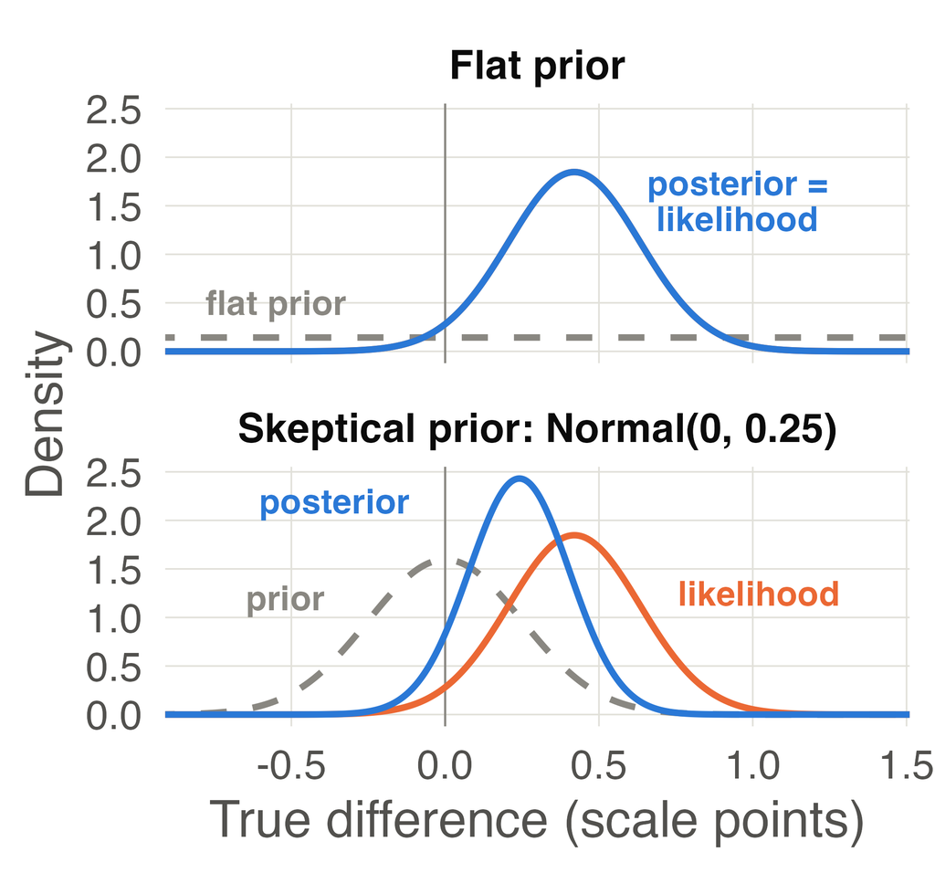

## Confidence vs. credible intervals

Confidence interval

- A claim about the *procedure*: if we repeated the study forever, 95% of the intervals built this way would capture the true difference.
- Whether this particular interval captured it is unknown.
- n = 50: [−0.01, 0.85]

Credible interval

- A claim about the *parameter*: given the model and prior, there’s a 95% probability the true difference is in this interval.
- This is the interpretation people often (incorrectly) give confidence intervals.
- n = 50, flat prior: [−0.01, 0.85]
- **Note**: with a flat prior and a simple model, the two intervals are numerically identical. The numbers match but the interpretations differ, and the interpretation is what goes in your results section.

## Priors are theories

- A prior can also formalize a theory’s prediction.
- Writing a theory as a prior forces you to say how big an effect it predicts:
  - **ADT** – viewers enjoy seeing a good character rewarded: δ ≈ Normal(0.3, 0.15).
  - **Craft** – enjoyment depends on how well the story is told, whatever the ending: δ = 0.
  - **Tragedy** – a good person suffering is moving, and moving stories are enjoyed more: δ ≈ Normal(−0.3, 0.15).
- This is a Bayesian version of Meehl’s (1967) argument: a theory that predicts only “some difference” is hard to refute, so confirming it tells us little.

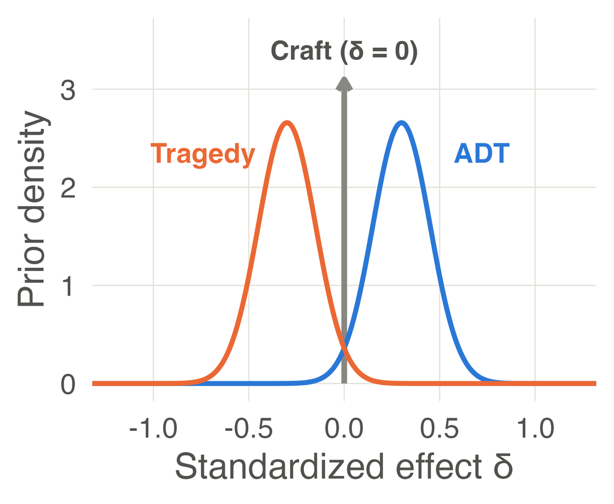

## The Bayes factor as a prediction contest

- Each theory’s prior implies what data you should see *before* you collect any.
- **Bayes factor** – the ratio of how well two theories predicted the data that actually came in: BF₁₀ = P(data | H₁) / P(data | H₀).
  - E.g. – BF = 5 means the data were five times more likely under one theory than the other.
- At n = 50, ADT out-predicts craft by about 5 to 1 and tragedy by about 41 to 1.
- At n = 150, those grow to about 300 and 1,000 to 1.
- JASP’s default alternative reaches only 1.12 at n = 50. It spreads its predictions over many effect sizes, so it gets less credit when a small effect appears.

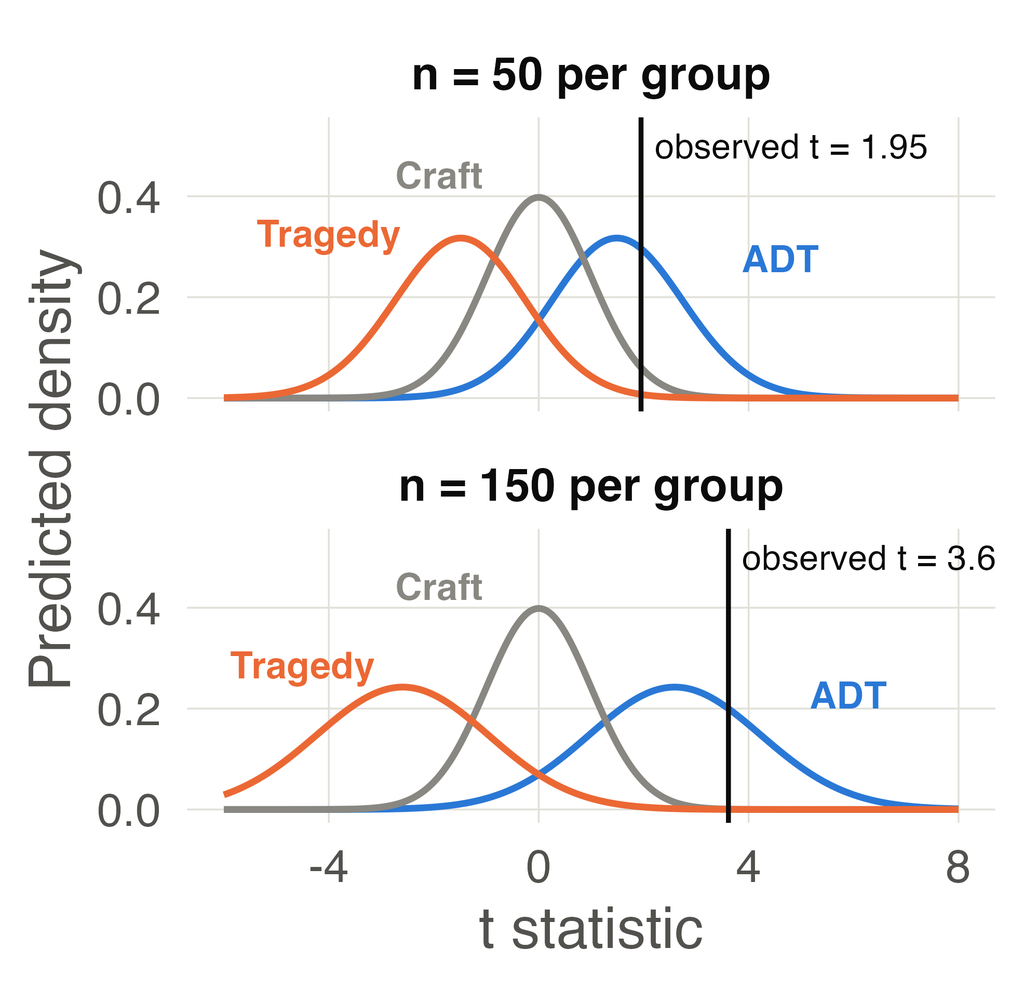

## Evidence for the null

- A *p* value can only indicate that the data are surprising under H₀. Failing to reject H₀ does not support it.
- A Bayes factor is symmetric: BF₀₁ = 1 / BF₁₀ can quantify evidence *for* the null (Rouder et al., 2009; Dienes, 2014).
  - E.g. – demo Scene 3: with a morally neutral character, ADT predicts *no* effect, and the data can support that.
- The frequentist route to “no meaningful effect” is an **equivalence test** against your smallest effect of interest (Lakens et al., 2018).
- …But a Bayes factor depends on how you specify the alternative. Wider priors predict bigger effects and get penalized when they don’t show up, so report a sensitivity check.

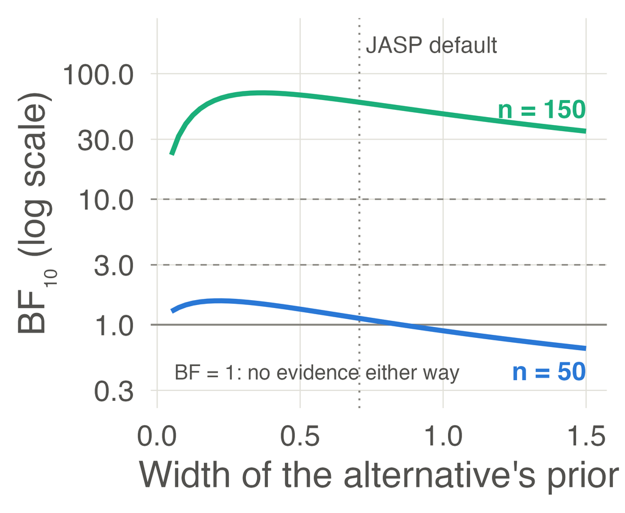

## Reading: Etz & Vandekerckhove (2018)

- A tutorial written for psychologists, opening a 2018 special issue of *Psychonomic Bulletin & Review* on Bayesian methods.
- It builds Bayesian inference from two basic laws of probability (the product and sum rules), with probability read as a state of incomplete knowledge.
- **Contributions:**
  - Seven worked examples (set, memorably, at Hogwarts) covering Bayes’ rule, parameter estimation, and model comparison.
  - Most of the math needs only college algebra, and each formula is paired with a figure or table.
  - For theory testing: a model that makes precise predictions can be confirmed more strongly than a vague one, and is also easier to disconfirm.

Assigned readingEtz, A., & Vandekerckhove, J. (2018). Introduction to Bayesian inference for psychology. *Psychonomic Bulletin & Review, 25*, 5–34.

1. Etz and Vandekerckhove treat probability as a state of incomplete knowledge. Does that make Bayesian conclusions "subjective"? Is a frequentist analysis any less dependent on the analyst's choices?

2. Pick a hypothesis from your own project. What prior would express it, and what result would count against it?

## Tradeoffs of Bayesian inference

Strengths

- Direct probability statements about parameters and hypotheses.
- Evidence *for* a model, including the null, relative to a rival.
- A formal home for theories (priors) and for cumulative evidence.
- Graceful handling of small samples and nested data.

Limitations

- Priors need to be justified, along with a check of how much they affect the result.
- It takes more computation, and some reviewers won’t know the reporting conventions yet (Kruschke, 2021).
- Flexible analysis choices can bias a Bayes factor just as they bias a *p* value.

Neither framework can tell you whether your estimate is causal.

## Demo – Scene 1 (continued) and Scene 2

- Back to **Scene 1**, “The Bayesian question”: flat vs. skeptical priors, and the Bayes factor.
- Then **Scene 2**: the prediction contest among ADT, craft, and tragedy.
- **Predict first**: if ADT is right, how much should its Bayes factor grow when n goes from 50 to 150?
- **Then**: reread the results sentence you wrote at the start. What would you change now?

## Roadmap

01

Frequentist inference

02

Bayesian inference

03

Causal identification

Now 600 viewers on a streaming platform *chose* which ending to watch. The rewarded ending’s viewers enjoyed the story 0.89 points more: *p* < .001, and an enormous Bayes factor.  
What would you conclude?

## Inference vs. identification

- **Inference** – given a model, what do the data say about a quantity, and how uncertain is it? Frequentist and Bayesian tools both live here.
- **Identification** – does that quantity equal the causal effect we care about? Only the design and our causal assumptions can answer this.
- The platform sample is twice our biggest experiment, yet its estimate (0.89) is more than double the true effect (0.36).
- A larger sample narrows the interval around a biased estimate, so the design problem remains.

Causal questionDoes the rewarded ending *increase* enjoyment?

↓**Identification**  
design + causal assumptions (a DAG)

Statistical estimandDifference in mean enjoyment between groups

↓**Inference**  
frequentist or Bayesian

Estimate0.89 [0.72, 1.06], *p* < .001

## Where DAGs came from

- Geneticist **Sewall Wright** invented path analysis around 1920, drawing his first path diagram for the inheritance of coat color in guinea pigs.
- Social scientists adopted path diagrams in the 1960s (Duncan, 1966), where they merged into linear structural equation models (SEM).
- In the 1980s, computer scientist **Judea Pearl** developed *Bayesian networks* – graphs for reasoning with probabilities – and in the 1990s gave their arrows a causal meaning (Pearl, 1995).
- Epidemiology adopted these **causal diagrams** first (Greenland, Pearl, & Robins, 1999). Psychology and communication are late adopters (Rohrer, 2018).

1920Wright's first path diagram (guinea pig coat color)

1921Wright, "Correlation and causation"

1966Duncan brings path analysis to sociology

1970sPath diagrams become linear SEMs

1985Pearl coins "Bayesian network"

1995Pearl, "Causal diagrams for empirical research"

1999Causal diagrams enter epidemiology

2018Rohrer brings DAGs to psychology

## What is a DAG?

- **Directed acyclic graph (DAG)** – a diagram of your assumptions about what causes what.
  - *Directed*: arrows point from cause to effect. *Acyclic*: no variable can cause itself by following arrows in a loop.
- An arrow means “might directly cause.” A **missing arrow** makes the stronger claim of no direct effect.
- DAGs are **nonparametric**: they say nothing about the size, sign, or form of an effect.
- In the experiment (top), the coin flip cuts every arrow into the ending. In the platform data (bottom), a **back-door path** runs through just-world preference.

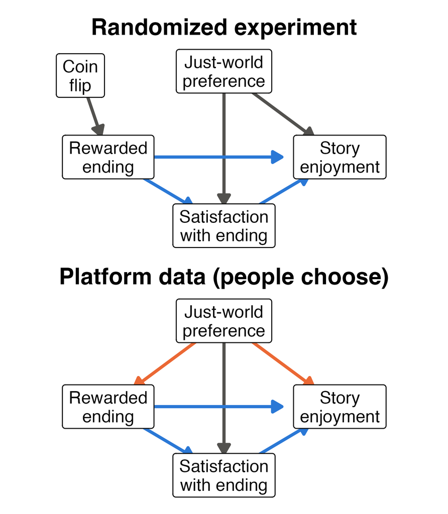

## DAGs vs. the box-and-arrow diagrams you know

| Box-and-arrow models | DAGs |
| --- | --- |
| Arrows can mean “predicts,” “is associated with,” or “H2.” | An arrow means one thing: a possible direct cause. |
| Moderation drawn as an arrow into an arrow. | No arrows into arrows. A moderator appears as another cause of the outcome. |
| Double-headed arrows and error terms. | Neither. Unmeasured common causes get their own node (U). |
| Shows the variables you measured. | Must also show the causes you *didn’t* measure. |
| Summarizes a model you’ll estimate. | Drawn *before* analysis, to decide what to adjust for. |

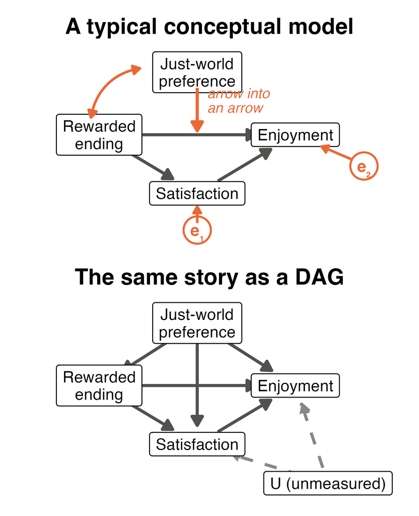

## Three building blocks

- Every DAG is built from three structures (Rohrer, 2018):
- **Chain** (X → M → Y) – M is a **mediator**. Controlling for it removes part of the effect you’re trying to estimate.
- **Fork** (X ← C → Y) – C is a **confounder**. It creates a non-causal association, and controlling for it removes that association.
- **Inverted fork** (X → S ← Y) – S is a **collider**. Controlling for it, or selecting your sample on it, *creates* an association that isn’t there.
  - E.g. – if journals publish studies that are rigorous *or* innovative, published studies will show a negative correlation between the two (Rohrer, 2018).

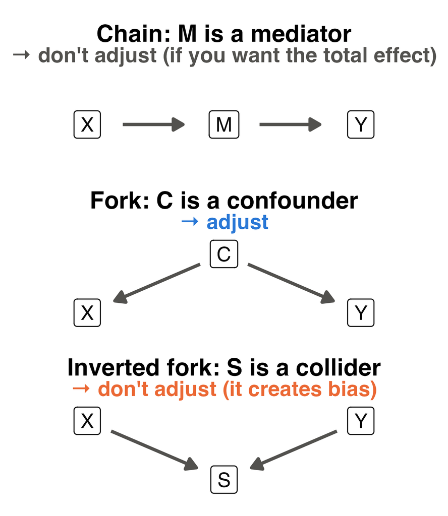

## Controls need causal justification

- Many of us learned to “control for” every plausible variable. Wysocki et al. (2022) show how this can increase bias.
- A control can remove bias (a confounder), add bias (a collider, or a mediator if you want the total effect), or leave bias unchanged and only affect precision.
- **Back-door criterion** – adjust for variables that block every non-causal path from X to Y, without blocking causal paths or opening collider paths.
- In the platform data, adjusting for just-world preference recovers the total effect. Adding satisfaction changes the estimand to the *direct* effect.

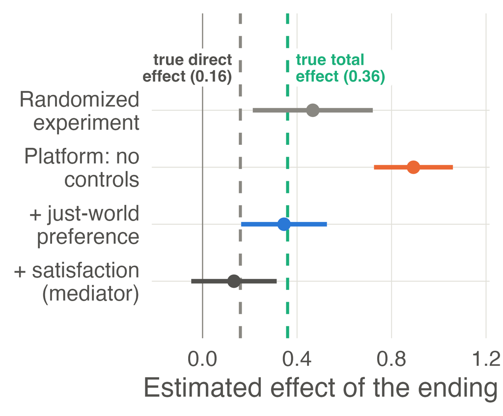

## Reading: Rohrer (2018)

- Rohrer starts from a common situation: the research question is causal, but the only data available are observational.
- She introduces DAGs as a tool for thinking clearly about how variables relate, using the effect of education on income as a running example.
- **Contributions:**
  - Why controlling for third variables works for confounders but backfires for colliders and mediators.
  - How unrepresentative samples and attrition act like controlling for a collider.
  - The argument that causal conclusions always rest on assumptions requiring domain knowledge, in experiments as well as observational work.
- Wysocki et al. (2022), the recommended follow-up, applies the same logic to how control variables are chosen in practice.

Assigned readingRohrer, J. M. (2018). Thinking clearly about correlations and causation: Graphical causal models for observational data. *Advances in Methods and Practices in Psychological Science, 1*(1), 27–42.

1. Think of a published communication study that "controlled for" a long list of covariates. Which of those might be mediators or colliders?

2. Many of our samples are selected on something: college students, people who finish the survey, people who post online. What might your sample be conditioned on, and what association could that create?

## Limitations of DAGs

- A DAG is only as good as the assumptions in it, and you mostly can’t learn those assumptions from the data you have.
- If a key confounder is unmeasured, no adjustment set exists. The DAG tells you that too, which is useful.
- It doesn’t give you an effect size, a functional form, or an inference framework.
- Its main value is making causal assumptions explicit so that reviewers (and you) can evaluate them.
- Rohrer (2018) concludes that causal inference from correlational data is very hard, which is a reason to state the assumptions openly.

## Demo – Scene 5: neither machine fixes the design

- Open the demo to **Scene 5**.
- **Predict first**: the platform has 600 viewers, twice our largest experiment. Will its estimate be closer to the truth? Which variables would you control for?
- **Watch for**: the coefficient plot. A narrow interval far from the dashed line is precise but biased.
- **Then**: sketch a DAG for your own project. What’s your exposure, what’s your outcome, and what causes both?

## Four questions you can ask of data

| Question | Framework | What it returns |
| --- | --- | --- |
| What should I **do**? | Neyman–Pearson testing | A decision with known long-run error rates |
| What do I now **believe**? | Bayesian estimation | A posterior: P(difference > 0) = .97 |
| What do the data say about **A vs. B**? | Likelihood ratios and Bayes factors | Relative evidence: ADT over tragedy, 41 to 1 |
| Is it **causal**? | None of the above | Design and assumptions, made explicit in a DAG |

- The first three are Royall’s (1997). The fourth has to be answered by the design.

## Summary

- **Frequentist inference** – probability is long-run frequency. A *p* value measures how compatible the data are with the whole model; it never gives the probability that a hypothesis is true.
- **Bayesian inference** – probability is degree of belief. Priors can formalize theories; posteriors and Bayes factors say what to believe and which theory predicted better.
- **Causal identification** – no inference framework fixes a design. A DAG makes causal assumptions explicit and tells you which variables to control for, and which to leave alone.
- **Your results sentence** – say what the analysis supports, then say what the design would need for the causal version.

## Reminders

- **Next**: reopen your September 14 project records (~25 min): estimand, one warranted results sentence, the causal assumption, and one remaining uncertainty.
- **Project Translation Note** – due Friday, October 2, at 11:59 p.m.
- **After class** – demo Scenes 3, 4, and 6; Wysocki et al. (2022) is the recommended follow-up to Rohrer.
- **Next week (October 5)** – Self-report and behavioral data.
- The theory-construction and prediction discussion moves to November 16.

QUESTIONS?